# 2024_02_27_ML_mit_brms

https://sammerk.github.io/JF/

Author

Samuel Merk

## Notiz zu letzter Woche

Nach dem Hören der [Quantitude Folge zu Simpson’s Paradox](https://quantitudepod.org/s5e16-simpsons-paradox/) würde ich sagen, dass es Fälle gibt die sowohl die Definiton von Ecological Fallacy und Simpson’s Paradox erfüllen aber weder

$$\text{Ecological Fallacy} \not\subseteq \text{Simpson's Paradox}$$

$$\text{Simpson's Paradox} \not\subseteq \text{Ecological Fallacy} \\$$

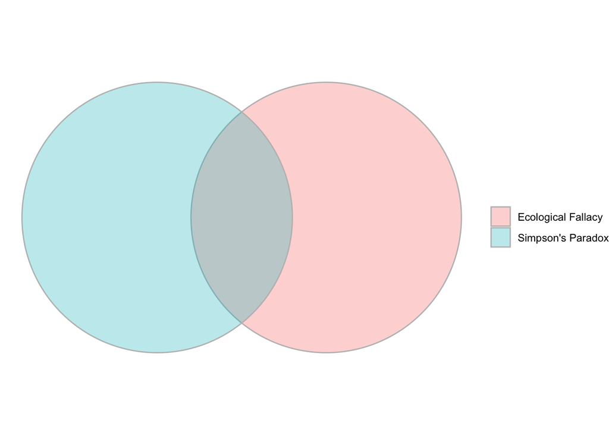

## Datengrundlage

### Florians Experiment zur effect size perception; plot vs. text

#### Gemeinsame Vignette

> A group of researchers investigated whether primary students improve their reading fluency more when they use an AI tutor than when a teacher corrects words. To answer this question, students were randomly assigned to one of two groups by flipping a coin. Over the course of four weeks, one group practiced reading with an AI tutor that gave students feedback on misread or mispronounced words, and the other group practiced reading with a teacher who corrected their mistakes as they read aloud together in class. After this four-week period, both groups were asked to complete a reading test.

#### Bedingung Plot

> The researchers received the following result after conducting the experiment:

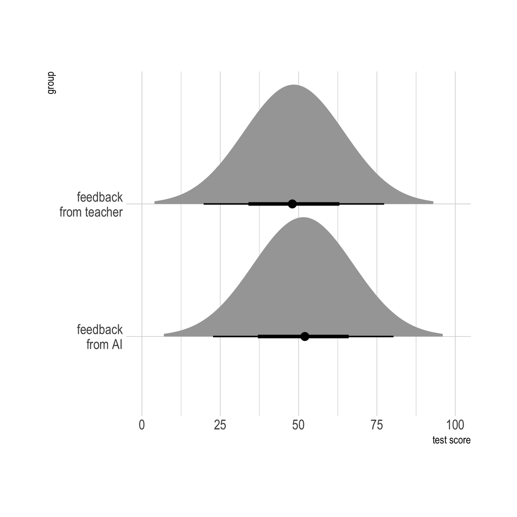

#### Bedingung Text

Eine AV ist die wahrgenommene Informativität `informativity` - ein Likert-Item mit sieben Stufen.

### Data Import

```r
# falls ihr das github-repo geforked habt
data <- read_csv("data/2024_02_27_jfdata.csv")
# falls ihr nicht github nutzt
data <- read_csv("https://bit.ly/merk129")
glimpse(data)
```

```
Rows: 240
Columns: 3
$ informativity <dbl> 3, 2, 2, 2, 2, 2, 5, 5, 5, 5, 4, 5, 4, 4, 4, 4, 4, 4, 3,…
$ stimulus_type <chr> "plot", "plot", "plot", "plot", "plot", "plot", "text", …
$ session       <chr> "fRWeEdsUFdCqnBpdzup4C_bk6zQnFkJV1Aj15z-iDe6PiaUS3OcAe-Z…
```

```r
data <-
  data |>
  mutate(
    # create short session(= participant) names
    session = as.factor(as.numeric(as.factor(session))),
    # create manual numeric dummy for text condition (for fiexed effects model)
    dummy_text = ifelse(stimulus_type == "text", 1, 0))
```

Die weiteren Variablen im Datensatz sind `stimulus_type` (die UV) und `session` (der Personidentifier und damit hier auch die Clustervariable).

## Visualisierung

Wie immer 😉, starten wir mit einem Plot des Effekts, der u.a. die Rohdaten enthält

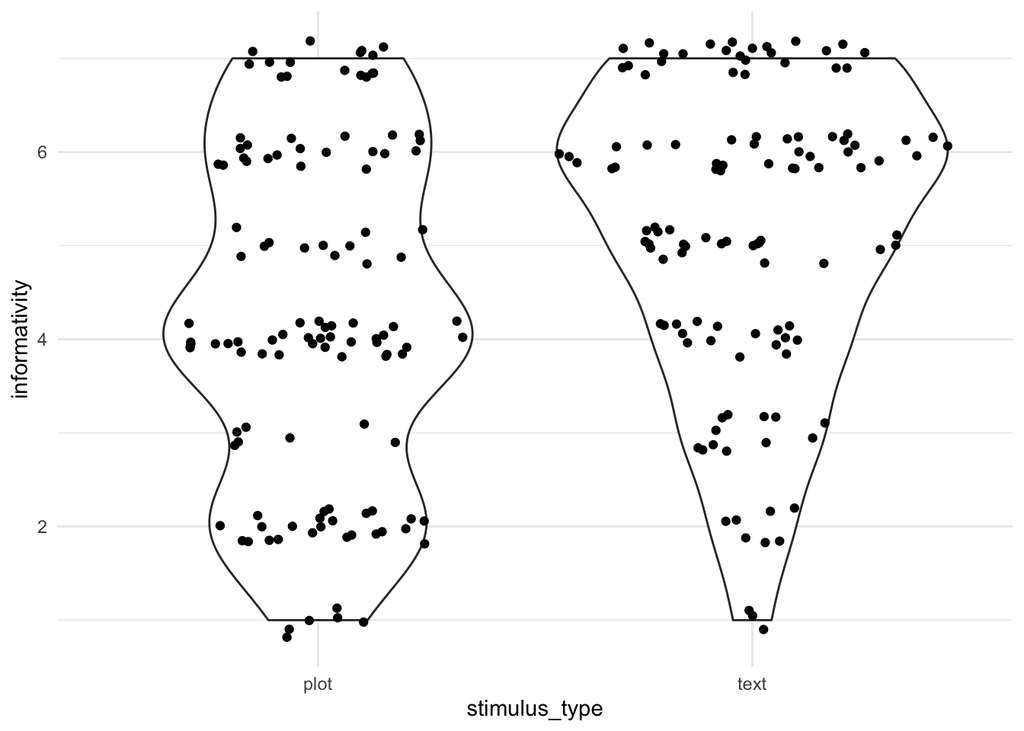

```r
# complete pooling
data |>
  ggplot(aes(stimulus_type, informativity)) +
  geom_violin() +
  geom_sina() +
  theme_minimal()
```

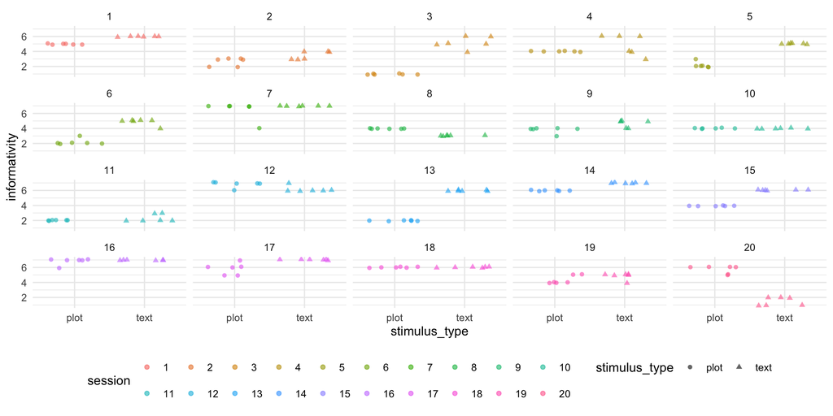

```r
# no pooling
data |>
  ggplot(aes(stimulus_type, informativity, color = session)) +
  geom_jitter(aes(shape = stimulus_type), height = .1, alpha = .6) +
  facet_wrap(~session) +
  theme_minimal() +
  theme(legend.position = "bottom") +
  guides(color=guide_legend(nrow=2,byrow=TRUE))
```

## ICC und Designeffect

```r
# compute ICC1
ICC1.lme(informativity, session, data)
```

```
[1] 0.6148212
```

```r
# compute DEFT for current clustersize (12)
design_effect(12, ICC1.lme(informativity, session, data))
```

```
[1] 7.763033
```

## Einfache lineare Dummyregression

```r
mod00 <- lm(informativity ~ dummy_text,
            data = data)

tab_model(
  mod00,
  dv.labels = c("OLS"),
  show.se = T)
```

|  | OLS |  |  |  |
| --- | --- | --- | --- | --- |
| Predictors | Estimates | std. Error | CI | p |
| (Intercept) | 4.24 | 0.16 | 3.93 – 4.55 | **<0.001** |
| dummy text | 0.85 | 0.22 | 0.41 – 1.29 | **<0.001** |
| Observations | 240 |  |  |  |
| R<sup>2</sup> / R<sup>2</sup> adjusted | 0.058 / 0.055 |  |  |  |

## Cluster Robust SE

```r
mod01 <- lm_robust(informativity ~ dummy_text,
                   cluster = session,
                   data = data)
tab_model(
  mod00,
  mod01,
  dv.labels = c("OLS", "Sandwich SE"),
  show.se = T
)
```

|  | OLS |  |  |  | Sandwich SE |  |  |  |
| --- | --- | --- | --- | --- | --- | --- | --- | --- |
| Predictors | Estimates | std. Error | CI | p | Estimates | std. Error | CI | p |
| (Intercept) | 4.24 | 0.16 | 3.93 – 4.55 | **<0.001** | 4.24 | 0.40 | 3.45 – 5.04 | **<0.001** |
| dummy text | 0.85 | 0.22 | 0.41 – 1.29 | **<0.001** | 0.85 | 0.41 | 0.05 – 1.65 | **0.038** |
| Observations | 240 |  |  |  | 240 |  |  |  |
| R<sup>2</sup> / R<sup>2</sup> adjusted | 0.058 / 0.055 |  |  |  | 0.058 / 0.055 |  |  |  |

## Fixed effects regression

```r
# add session as dummycoded predictor and remove intercept via `-1`
mod02 <- lm(informativity ~ dummy_text + session - 1,
           data = data)

tab_model(
  mod00,
  mod01,
  mod02,
  dv.labels = c("OLS", "Sandwich SE", "Fixed Effects"),
  show.se = T
)
```

|  | OLS |  |  |  | Sandwich SE |  |  |  | Fixed Effects |  |  |  |
| --- | --- | --- | --- | --- | --- | --- | --- | --- | --- | --- | --- | --- |
| Predictors | Estimates | std. Error | CI | p | Estimates | std. Error | CI | p | Estimates | std. Error | CI | p |
| (Intercept) | 4.24 | 0.16 | 3.93 – 4.55 | **<0.001** | 4.24 | 0.40 | 3.45 – 5.04 | **<0.001** |  |  |  |  |
| dummy text | 0.85 | 0.22 | 0.41 – 1.29 | **<0.001** | 0.85 | 0.41 | 0.05 – 1.65 | **0.038** | 0.85 | 0.13 | 0.59 – 1.11 | **<0.001** |
| session [1] |  |  |  |  |  |  |  |  | 5.08 | 0.30 | 4.48 – 5.67 | **<0.001** |
| session [2] |  |  |  |  |  |  |  |  | 2.66 | 0.30 | 2.06 – 3.25 | **<0.001** |
| session [3] |  |  |  |  |  |  |  |  | 2.66 | 0.30 | 2.06 – 3.25 | **<0.001** |
| session [4] |  |  |  |  |  |  |  |  | 3.99 | 0.30 | 3.40 – 4.59 | **<0.001** |
| session [5] |  |  |  |  |  |  |  |  | 3.16 | 0.30 | 2.56 – 3.75 | **<0.001** |
| session [6] |  |  |  |  |  |  |  |  | 3.08 | 0.30 | 2.48 – 3.67 | **<0.001** |
| session [7] |  |  |  |  |  |  |  |  | 6.32 | 0.30 | 5.73 – 6.92 | **<0.001** |
| session [8] |  |  |  |  |  |  |  |  | 3.07 | 0.30 | 2.48 – 3.67 | **<0.001** |
| session [9] |  |  |  |  |  |  |  |  | 3.83 | 0.30 | 3.23 – 4.42 | **<0.001** |
| session [10] |  |  |  |  |  |  |  |  | 3.57 | 0.30 | 2.98 – 4.17 | **<0.001** |
| session [11] |  |  |  |  |  |  |  |  | 1.74 | 0.30 | 1.15 – 2.34 | **<0.001** |
| session [12] |  |  |  |  |  |  |  |  | 6.07 | 0.30 | 5.48 – 6.67 | **<0.001** |
| session [13] |  |  |  |  |  |  |  |  | 3.58 | 0.30 | 2.98 – 4.17 | **<0.001** |
| session [14] |  |  |  |  |  |  |  |  | 6.08 | 0.30 | 5.48 – 6.67 | **<0.001** |
| session [15] |  |  |  |  |  |  |  |  | 4.57 | 0.30 | 3.98 – 5.17 | **<0.001** |
| session [16] |  |  |  |  |  |  |  |  | 6.49 | 0.30 | 5.90 – 7.09 | **<0.001** |
| session [17] |  |  |  |  |  |  |  |  | 5.99 | 0.30 | 5.40 – 6.59 | **<0.001** |
| session [18] |  |  |  |  |  |  |  |  | 5.57 | 0.30 | 4.98 – 6.17 | **<0.001** |
| session [19] |  |  |  |  |  |  |  |  | 4.16 | 0.30 | 3.56 – 4.75 | **<0.001** |
| session [20] |  |  |  |  |  |  |  |  | 3.16 | 0.30 | 2.56 – 3.75 | **<0.001** |
| Observations | 240 |  |  |  | 240 |  |  |  | 240 |  |  |  |
| R<sup>2</sup> / R<sup>2</sup> adjusted | 0.058 / 0.055 |  |  |  | 0.058 / 0.055 |  |  |  | 0.962 / 0.958 |  |  |  |

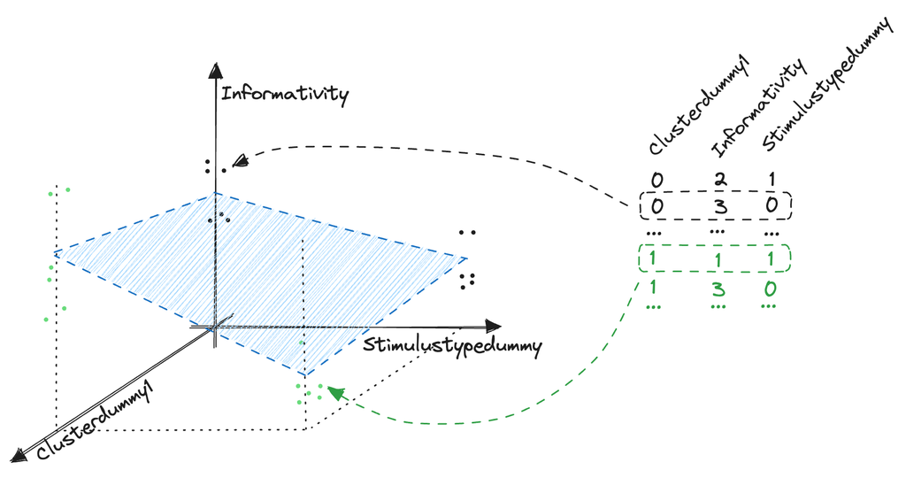

Darstellung des Fixed Effects Modells mit Minimaldaten

## Multi-level model

```r
# random intercept model
mod03 <- lmer(informativity ~ dummy_text + (1|session),
           data = data)

tab_model(
  mod00,
  mod01,
  mod02,
  mod03,
  dv.labels = c("OLS",
                "Sandwich SE",
                "Fixed Effects",
                "Multi-Level"),
  show.se = T
)
```

|  | OLS |  |  |  | Sandwich SE |  |  |  | Fixed Effects |  |  |  | Multi-Level |  |  |  |
| --- | --- | --- | --- | --- | --- | --- | --- | --- | --- | --- | --- | --- | --- | --- | --- | --- |
| Predictors | Estimates | std. Error | CI | p | Estimates | std. Error | CI | p | Estimates | std. Error | CI | p | Estimates | std. Error | CI | p |
| (Intercept) | 4.24 | 0.16 | 3.93 – 4.55 | **<0.001** | 4.24 | 0.40 | 3.45 – 5.04 | **<0.001** |  |  |  |  | 4.24 | 0.33 | 3.60 – 4.89 | **<0.001** |
| dummy text | 0.85 | 0.22 | 0.41 – 1.29 | **<0.001** | 0.85 | 0.41 | 0.05 – 1.65 | **0.038** | 0.85 | 0.13 | 0.59 – 1.11 | **<0.001** | 0.85 | 0.13 | 0.59 – 1.11 | **<0.001** |
| session [1] |  |  |  |  |  |  |  |  | 5.08 | 0.30 | 4.48 – 5.67 | **<0.001** |  |  |  |  |
| session [2] |  |  |  |  |  |  |  |  | 2.66 | 0.30 | 2.06 – 3.25 | **<0.001** |  |  |  |  |
| session [3] |  |  |  |  |  |  |  |  | 2.66 | 0.30 | 2.06 – 3.25 | **<0.001** |  |  |  |  |
| session [4] |  |  |  |  |  |  |  |  | 3.99 | 0.30 | 3.40 – 4.59 | **<0.001** |  |  |  |  |
| session [5] |  |  |  |  |  |  |  |  | 3.16 | 0.30 | 2.56 – 3.75 | **<0.001** |  |  |  |  |
| session [6] |  |  |  |  |  |  |  |  | 3.08 | 0.30 | 2.48 – 3.67 | **<0.001** |  |  |  |  |
| session [7] |  |  |  |  |  |  |  |  | 6.32 | 0.30 | 5.73 – 6.92 | **<0.001** |  |  |  |  |
| session [8] |  |  |  |  |  |  |  |  | 3.07 | 0.30 | 2.48 – 3.67 | **<0.001** |  |  |  |  |
| session [9] |  |  |  |  |  |  |  |  | 3.83 | 0.30 | 3.23 – 4.42 | **<0.001** |  |  |  |  |
| session [10] |  |  |  |  |  |  |  |  | 3.57 | 0.30 | 2.98 – 4.17 | **<0.001** |  |  |  |  |
| session [11] |  |  |  |  |  |  |  |  | 1.74 | 0.30 | 1.15 – 2.34 | **<0.001** |  |  |  |  |
| session [12] |  |  |  |  |  |  |  |  | 6.07 | 0.30 | 5.48 – 6.67 | **<0.001** |  |  |  |  |
| session [13] |  |  |  |  |  |  |  |  | 3.58 | 0.30 | 2.98 – 4.17 | **<0.001** |  |  |  |  |
| session [14] |  |  |  |  |  |  |  |  | 6.08 | 0.30 | 5.48 – 6.67 | **<0.001** |  |  |  |  |
| session [15] |  |  |  |  |  |  |  |  | 4.57 | 0.30 | 3.98 – 5.17 | **<0.001** |  |  |  |  |
| session [16] |  |  |  |  |  |  |  |  | 6.49 | 0.30 | 5.90 – 7.09 | **<0.001** |  |  |  |  |
| session [17] |  |  |  |  |  |  |  |  | 5.99 | 0.30 | 5.40 – 6.59 | **<0.001** |  |  |  |  |
| session [18] |  |  |  |  |  |  |  |  | 5.57 | 0.30 | 4.98 – 6.17 | **<0.001** |  |  |  |  |
| session [19] |  |  |  |  |  |  |  |  | 4.16 | 0.30 | 3.56 – 4.75 | **<0.001** |  |  |  |  |
| session [20] |  |  |  |  |  |  |  |  | 3.16 | 0.30 | 2.56 – 3.75 | **<0.001** |  |  |  |  |
| Random Effects |  |  |  |  |  |  |  |  |  |  |  |  |  |  |  |  |
| σ<sup>2</sup> |  |  |  |  |  |  |  |  |  |  |  |  | 1.04 |  |  |  |
| τ<sub>00</sub> |  |  |  |  |  |  |  |  |  |  |  |  | 1.98 <sub>session</sub> |  |  |  |
| ICC |  |  |  |  |  |  |  |  |  |  |  |  | 0.66 |  |  |  |
| N |  |  |  |  |  |  |  |  |  |  |  |  | 20 <sub>session</sub> |  |  |  |
| Observations | 240 |  |  |  | 240 |  |  |  | 240 |  |  |  | 240 |  |  |  |
| R<sup>2</sup> / R<sup>2</sup> adjusted | 0.058 / 0.055 |  |  |  | 0.058 / 0.055 |  |  |  | 0.962 / 0.958 |  |  |  | 0.057 / 0.676 |  |  |  |

## Bayesian simple linear regression

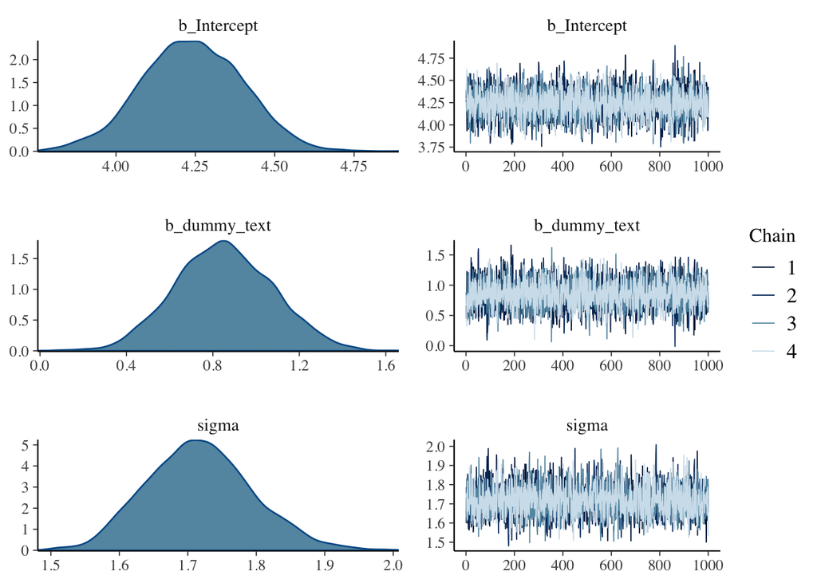

```r
mod04 <- brm(informativity ~ dummy_text, data = data)
# diagnose the MCMC
plot(mod04)
```

```
Using 10 posterior draws for ppc type 'dens_overlay' by default.
```

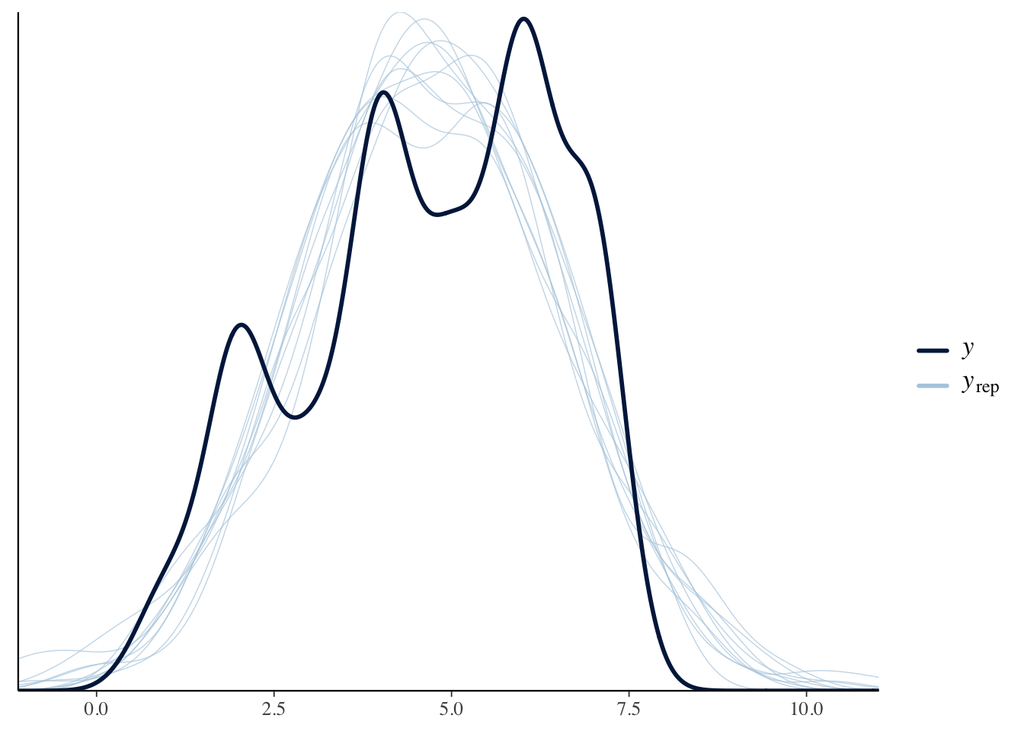

```r
# check posterior predictives
pp_check(mod04)
```

```r
# look a the posterior
describe_posterior(mod04)
```

```
Summary of Posterior Distribution

Parameter   | Median |       95% CI |     pd |          ROPE | % in ROPE |  Rhat |     ESS
------------------------------------------------------------------------------------------
(Intercept) |   4.24 | [3.92, 4.55] |   100% | [-0.18, 0.18] |        0% | 1.000 | 4102.00
dummy_text  |   0.85 | [0.42, 1.30] | 99.98% | [-0.18, 0.18] |        0% | 1.000 | 4067.00
```

```r
# caculate the probability of direction
pd(mod04)
```

```
Probability of Direction

Parameter   |     pd
--------------------
(Intercept) |   100%
dummy_text  | 99.98%
```

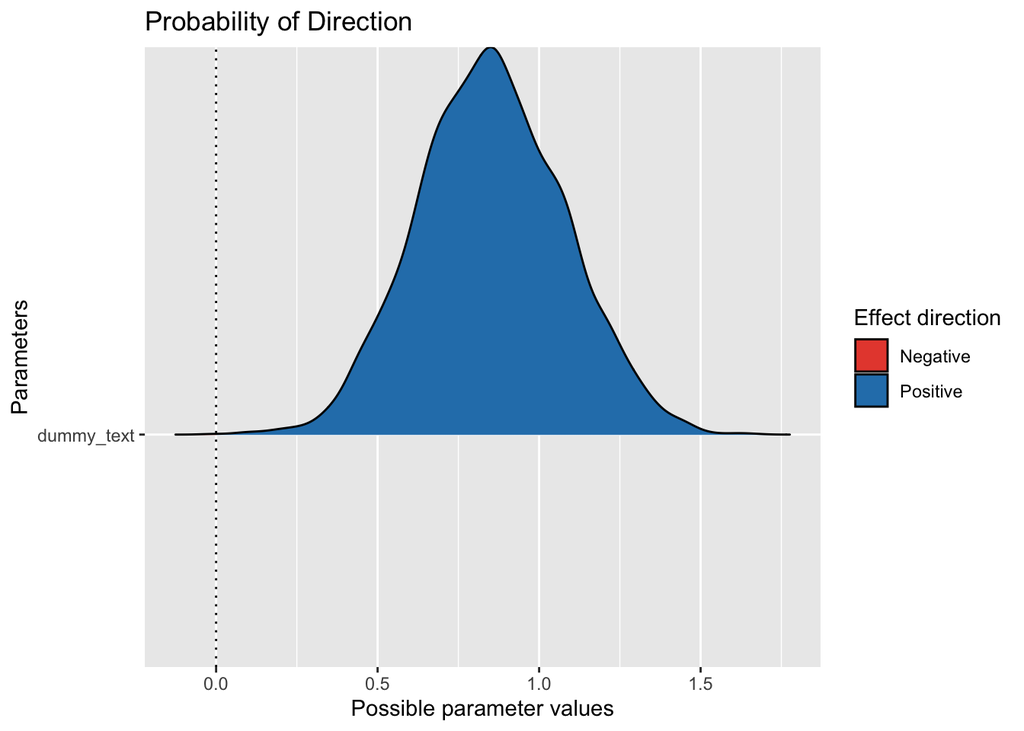

```r
plot(pd(mod04))
```

```r
# rope
rope(mod04, range = c(-.5, .5))
```

```
# Proportion of samples inside the ROPE [-0.50, 0.50]:

Parameter  | inside ROPE
------------------------
Intercept  |      0.00 %
dummy_text |      3.61 %
```

```r
# compare models
tab_model(
  mod00,
  mod01,
  mod02,
  mod03,
  mod04,
  dv.labels = c("OLS",
                "Sandwich SE",
                "Fixed Effects",
                "Multi-Level",
                "Bayesian simple Reg."),
  show.se = T
)
```

|  | OLS |  |  |  | Sandwich SE |  |  |  | Fixed Effects |  |  |  | Multi-Level |  |  |  | Bayesian simple Reg. |  |  |
| --- | --- | --- | --- | --- | --- | --- | --- | --- | --- | --- | --- | --- | --- | --- | --- | --- | --- | --- | --- |
| Predictors | Estimates | std. Error | CI | p | Estimates | std. Error | CI | p | Estimates | std. Error | CI | p | Estimates | std. Error | CI | p | Estimates | std. Error | CI (95%) |
| (Intercept) | 4.24 | 0.16 | 3.93 – 4.55 | **<0.001** | 4.24 | 0.40 | 3.45 – 5.04 | **<0.001** |  |  |  |  | 4.24 | 0.33 | 3.60 – 4.89 | **<0.001** |  |  |  |
| dummy text | 0.85 | 0.22 | 0.41 – 1.29 | **<0.001** | 0.85 | 0.41 | 0.05 – 1.65 | **0.038** | 0.85 | 0.13 | 0.59 – 1.11 | **<0.001** | 0.85 | 0.13 | 0.59 – 1.11 | **<0.001** | 0.85 | 0.23 | 0.42 – 1.30 |
| session1 |  |  |  |  |  |  |  |  | 5.08 | 0.30 | 4.48 – 5.67 | **<0.001** |  |  |  |  |  |  |  |
| session2 |  |  |  |  |  |  |  |  | 2.66 | 0.30 | 2.06 – 3.25 | **<0.001** |  |  |  |  |  |  |  |
| session3 |  |  |  |  |  |  |  |  | 2.66 | 0.30 | 2.06 – 3.25 | **<0.001** |  |  |  |  |  |  |  |
| session4 |  |  |  |  |  |  |  |  | 3.99 | 0.30 | 3.40 – 4.59 | **<0.001** |  |  |  |  |  |  |  |
| session5 |  |  |  |  |  |  |  |  | 3.16 | 0.30 | 2.56 – 3.75 | **<0.001** |  |  |  |  |  |  |  |
| session6 |  |  |  |  |  |  |  |  | 3.08 | 0.30 | 2.48 – 3.67 | **<0.001** |  |  |  |  |  |  |  |
| session7 |  |  |  |  |  |  |  |  | 6.32 | 0.30 | 5.73 – 6.92 | **<0.001** |  |  |  |  |  |  |  |
| session8 |  |  |  |  |  |  |  |  | 3.07 | 0.30 | 2.48 – 3.67 | **<0.001** |  |  |  |  |  |  |  |
| session9 |  |  |  |  |  |  |  |  | 3.83 | 0.30 | 3.23 – 4.42 | **<0.001** |  |  |  |  |  |  |  |
| session10 |  |  |  |  |  |  |  |  | 3.57 | 0.30 | 2.98 – 4.17 | **<0.001** |  |  |  |  |  |  |  |
| session11 |  |  |  |  |  |  |  |  | 1.74 | 0.30 | 1.15 – 2.34 | **<0.001** |  |  |  |  |  |  |  |
| session12 |  |  |  |  |  |  |  |  | 6.07 | 0.30 | 5.48 – 6.67 | **<0.001** |  |  |  |  |  |  |  |
| session13 |  |  |  |  |  |  |  |  | 3.58 | 0.30 | 2.98 – 4.17 | **<0.001** |  |  |  |  |  |  |  |
| session14 |  |  |  |  |  |  |  |  | 6.08 | 0.30 | 5.48 – 6.67 | **<0.001** |  |  |  |  |  |  |  |
| session15 |  |  |  |  |  |  |  |  | 4.57 | 0.30 | 3.98 – 5.17 | **<0.001** |  |  |  |  |  |  |  |
| session16 |  |  |  |  |  |  |  |  | 6.49 | 0.30 | 5.90 – 7.09 | **<0.001** |  |  |  |  |  |  |  |
| session17 |  |  |  |  |  |  |  |  | 5.99 | 0.30 | 5.40 – 6.59 | **<0.001** |  |  |  |  |  |  |  |
| session18 |  |  |  |  |  |  |  |  | 5.57 | 0.30 | 4.98 – 6.17 | **<0.001** |  |  |  |  |  |  |  |
| session19 |  |  |  |  |  |  |  |  | 4.16 | 0.30 | 3.56 – 4.75 | **<0.001** |  |  |  |  |  |  |  |
| session20 |  |  |  |  |  |  |  |  | 3.16 | 0.30 | 2.56 – 3.75 | **<0.001** |  |  |  |  |  |  |  |
| Intercept |  |  |  |  |  |  |  |  |  |  |  |  |  |  |  |  | 4.24 | 0.16 | 3.92 – 4.55 |
| Random Effects |  |  |  |  |  |  |  |  |  |  |  |  |  |  |  |  |  |  |  |
| σ<sup>2</sup> |  |  |  |  |  |  |  |  |  |  |  |  | 1.04 |  |  |  |  |  |  |
| τ<sub>00</sub> |  |  |  |  |  |  |  |  |  |  |  |  | 1.98 <sub>session</sub> |  |  |  |  |  |  |
| ICC |  |  |  |  |  |  |  |  |  |  |  |  | 0.66 |  |  |  |  |  |  |
| N |  |  |  |  |  |  |  |  |  |  |  |  | 20 <sub>session</sub> |  |  |  |  |  |  |
| Observations | 240 |  |  |  | 240 |  |  |  | 240 |  |  |  | 240 |  |  |  | 240 |  |  |
| R<sup>2</sup> / R<sup>2</sup> adjusted | 0.058 / 0.055 |  |  |  | 0.058 / 0.055 |  |  |  | 0.962 / 0.958 |  |  |  | 0.057 / 0.676 |  |  |  | 0.058 |  |  |

## Bayesian multi-level regression modell

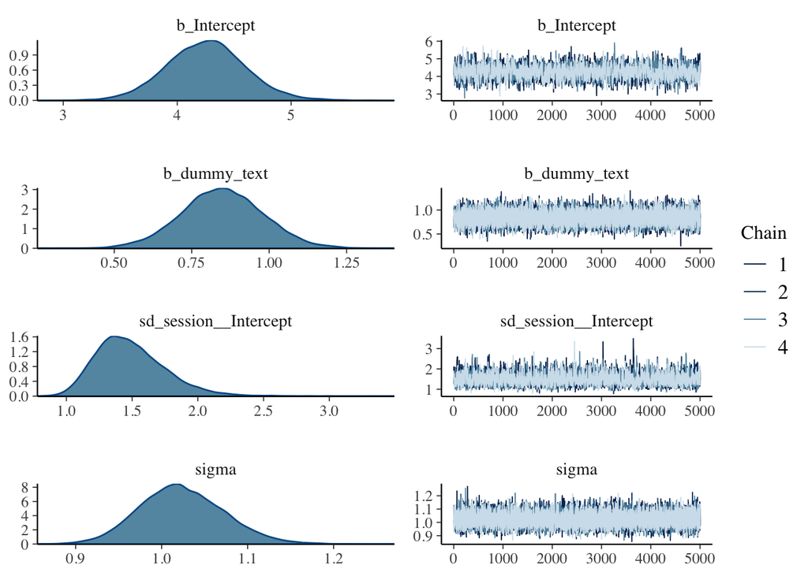

```r
mod05 <- brm(informativity ~ dummy_text + (1 | session),
             iter = 10000,
             data = data)
# diagnose the MCMC
plot(mod05)
```

```
Using 10 posterior draws for ppc type 'dens_overlay' by default.
```

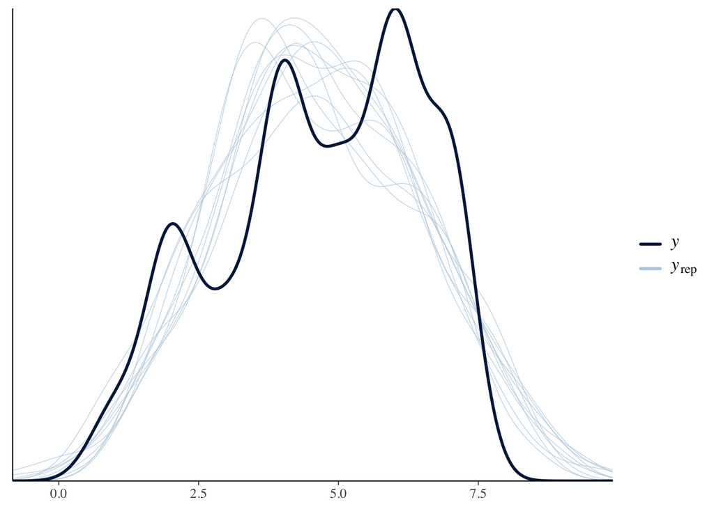

```r
# check posterior predictives
pp_check(mod05)
```

```r
# look a the posterior
describe_posterior(mod05)
```

```
Summary of Posterior Distribution

Parameter   | Median |       95% CI |   pd |          ROPE | % in ROPE |  Rhat |      ESS
-----------------------------------------------------------------------------------------
(Intercept) |   4.26 | [3.58, 4.95] | 100% | [-0.18, 0.18] |        0% | 1.001 |  2124.00
dummy_text  |   0.85 | [0.59, 1.11] | 100% | [-0.18, 0.18] |        0% | 1.000 | 16221.00
```

```r
# caculate the probability of direction
pd(mod05)
```

```
Probability of Direction

Parameter   |   pd
------------------
(Intercept) | 100%
dummy_text  | 100%
```

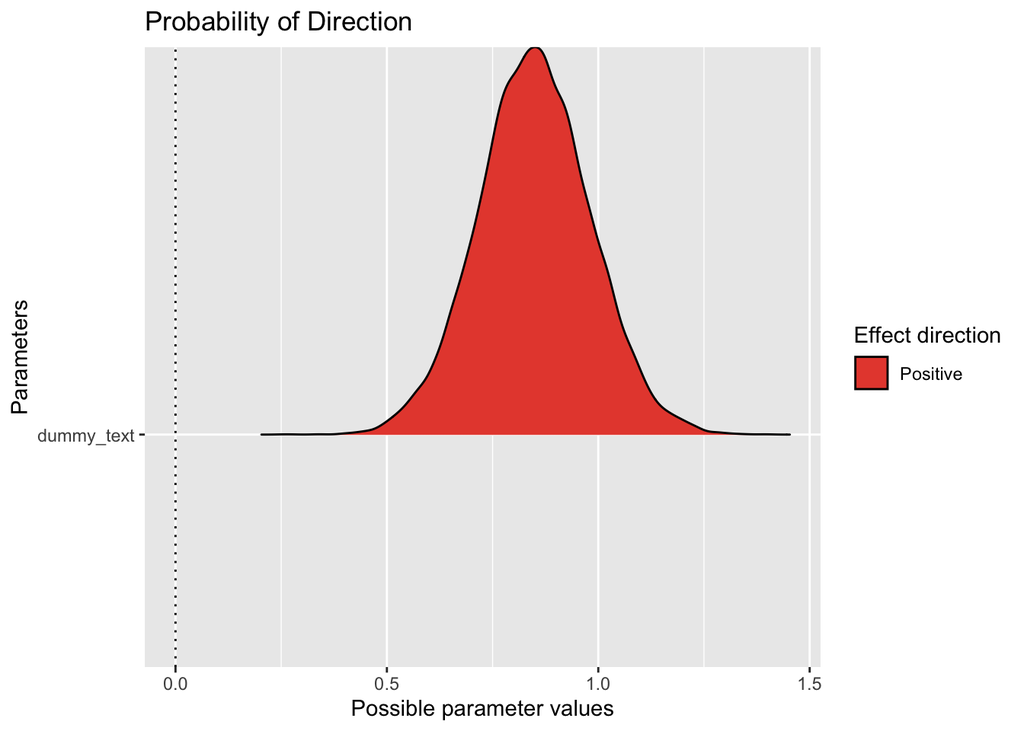

```r
plot(pd(mod05))
```

```r
# rope
rope(mod05, range = c(-.5, .5))
```

```
# Proportion of samples inside the ROPE [-0.50, 0.50]:

Parameter  | inside ROPE
------------------------
Intercept  |      0.00 %
dummy_text |      0.00 %
```

```r
# compare models
tab_model(
  mod00,
  mod01,
  mod02,
  mod03,
  mod04,
  mod05,
  dv.labels = c("OLS",
                "Sandwich SE",
                "Fixed Effects",
                "Multi-Level",
                "Bayesian simple Reg.",
                "Bayes. multi-level"),
  show.se = T
)
```

|  | OLS |  |  |  | Sandwich SE |  |  |  | Fixed Effects |  |  |  | Multi-Level |  |  |  | Bayesian simple Reg. |  |  | Bayes. multi-level |  |  |
| --- | --- | --- | --- | --- | --- | --- | --- | --- | --- | --- | --- | --- | --- | --- | --- | --- | --- | --- | --- | --- | --- | --- |
| Predictors | Estimates | std. Error | CI | p | Estimates | std. Error | CI | p | Estimates | std. Error | CI | p | Estimates | std. Error | CI | p | Estimates | std. Error | CI (95%) | Estimates | std. Error | CI (95%) |
| (Intercept) | 4.24 | 0.16 | 3.93 – 4.55 | **<0.001** | 4.24 | 0.40 | 3.45 – 5.04 | **<0.001** |  |  |  |  | 4.24 | 0.33 | 3.60 – 4.89 | **<0.001** |  |  |  |  |  |  |
| dummy text | 0.85 | 0.22 | 0.41 – 1.29 | **<0.001** | 0.85 | 0.41 | 0.05 – 1.65 | **0.038** | 0.85 | 0.13 | 0.59 – 1.11 | **<0.001** | 0.85 | 0.13 | 0.59 – 1.11 | **<0.001** | 0.85 | 0.23 | 0.42 – 1.30 | 0.85 | 0.13 | 0.59 – 1.11 |
| session1 |  |  |  |  |  |  |  |  | 5.08 | 0.30 | 4.48 – 5.67 | **<0.001** |  |  |  |  |  |  |  |  |  |  |
| session2 |  |  |  |  |  |  |  |  | 2.66 | 0.30 | 2.06 – 3.25 | **<0.001** |  |  |  |  |  |  |  |  |  |  |
| session3 |  |  |  |  |  |  |  |  | 2.66 | 0.30 | 2.06 – 3.25 | **<0.001** |  |  |  |  |  |  |  |  |  |  |
| session4 |  |  |  |  |  |  |  |  | 3.99 | 0.30 | 3.40 – 4.59 | **<0.001** |  |  |  |  |  |  |  |  |  |  |
| session5 |  |  |  |  |  |  |  |  | 3.16 | 0.30 | 2.56 – 3.75 | **<0.001** |  |  |  |  |  |  |  |  |  |  |
| session6 |  |  |  |  |  |  |  |  | 3.08 | 0.30 | 2.48 – 3.67 | **<0.001** |  |  |  |  |  |  |  |  |  |  |
| session7 |  |  |  |  |  |  |  |  | 6.32 | 0.30 | 5.73 – 6.92 | **<0.001** |  |  |  |  |  |  |  |  |  |  |
| session8 |  |  |  |  |  |  |  |  | 3.07 | 0.30 | 2.48 – 3.67 | **<0.001** |  |  |  |  |  |  |  |  |  |  |
| session9 |  |  |  |  |  |  |  |  | 3.83 | 0.30 | 3.23 – 4.42 | **<0.001** |  |  |  |  |  |  |  |  |  |  |
| session10 |  |  |  |  |  |  |  |  | 3.57 | 0.30 | 2.98 – 4.17 | **<0.001** |  |  |  |  |  |  |  |  |  |  |
| session11 |  |  |  |  |  |  |  |  | 1.74 | 0.30 | 1.15 – 2.34 | **<0.001** |  |  |  |  |  |  |  |  |  |  |
| session12 |  |  |  |  |  |  |  |  | 6.07 | 0.30 | 5.48 – 6.67 | **<0.001** |  |  |  |  |  |  |  |  |  |  |
| session13 |  |  |  |  |  |  |  |  | 3.58 | 0.30 | 2.98 – 4.17 | **<0.001** |  |  |  |  |  |  |  |  |  |  |
| session14 |  |  |  |  |  |  |  |  | 6.08 | 0.30 | 5.48 – 6.67 | **<0.001** |  |  |  |  |  |  |  |  |  |  |
| session15 |  |  |  |  |  |  |  |  | 4.57 | 0.30 | 3.98 – 5.17 | **<0.001** |  |  |  |  |  |  |  |  |  |  |
| session16 |  |  |  |  |  |  |  |  | 6.49 | 0.30 | 5.90 – 7.09 | **<0.001** |  |  |  |  |  |  |  |  |  |  |
| session17 |  |  |  |  |  |  |  |  | 5.99 | 0.30 | 5.40 – 6.59 | **<0.001** |  |  |  |  |  |  |  |  |  |  |
| session18 |  |  |  |  |  |  |  |  | 5.57 | 0.30 | 4.98 – 6.17 | **<0.001** |  |  |  |  |  |  |  |  |  |  |
| session19 |  |  |  |  |  |  |  |  | 4.16 | 0.30 | 3.56 – 4.75 | **<0.001** |  |  |  |  |  |  |  |  |  |  |
| session20 |  |  |  |  |  |  |  |  | 3.16 | 0.30 | 2.56 – 3.75 | **<0.001** |  |  |  |  |  |  |  |  |  |  |
| Intercept |  |  |  |  |  |  |  |  |  |  |  |  |  |  |  |  | 4.24 | 0.16 | 3.92 – 4.55 | 4.26 | 0.34 | 3.58 – 4.95 |
| Random Effects |  |  |  |  |  |  |  |  |  |  |  |  |  |  |  |  |  |  |  |  |  |  |
| σ<sup>2</sup> |  |  |  |  |  |  |  |  |  |  |  |  | 1.04 |  |  |  |  |  |  | 1.05 |  |  |
| τ<sub>00</sub> |  |  |  |  |  |  |  |  |  |  |  |  | 1.98 <sub>session</sub> |  |  |  |  |  |  | 2.22 <sub>session</sub> |  |  |
| ICC |  |  |  |  |  |  |  |  |  |  |  |  | 0.66 |  |  |  |  |  |  | 0.68 |  |  |
| N |  |  |  |  |  |  |  |  |  |  |  |  | 20 <sub>session</sub> |  |  |  |  |  |  | 20 <sub>session</sub> |  |  |
| Observations | 240 |  |  |  | 240 |  |  |  | 240 |  |  |  | 240 |  |  |  | 240 |  |  | 240 |  |  |
| R<sup>2</sup> / R<sup>2</sup> adjusted | 0.058 / 0.055 |  |  |  | 0.058 / 0.055 |  |  |  | 0.962 / 0.958 |  |  |  | 0.057 / 0.676 |  |  |  | 0.058 |  |  | 0.058 / 0.667 |  |  |